# Áreas

Geometría Euclidiana

Sergio Ruminot

Agustina Aramayo

26 mayo 2024

# **Primer clase**

# **Áreas**

1. ¿A qué objetos geométricos del plano le podemos observar el área?
2. ¿Qué es el área de un polígono?

## **Postulados**

## **Postulado 1**

A toda región poligonal $\mathrm{R}$, le corresponde un **número real positivo único** llamado área, al que designaremos:
$$\mathrm{A}_R$$

## **Postulado 2**

Los triángulos congruentes tienen áreas iguales.

## **Postulado 3**

Si una región $R$ es la unión de dos regiones $R_1$ y $R_2$ entonces:

$$A_R=A_{R_1}+A_{R_2}$$

## **Postulado 4**

El área de una **región rectangular** es el producto de las longitudes de los lados consecutivos. Esto se expresa de la siguiente manera:

$$A_{rect}=base\cdot altura=b\cdot
h$$

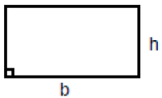

## **Rectángulo**

Es el cuadrilátero que tiene sus cuatro ángulos rectos

## **Clasificación de Cuadriláteros**

**Definición:** Polígono cerrado de 4 lados

### **Clasificación de paralelogramos**

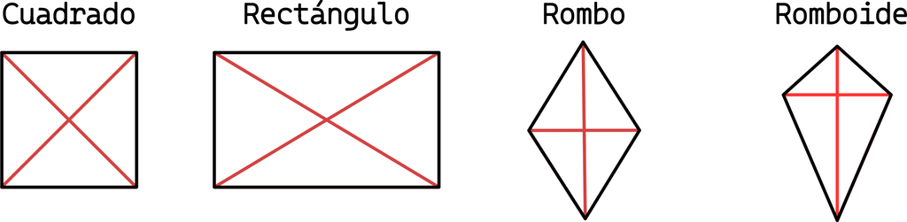

### **Clasificación de Trapecios**

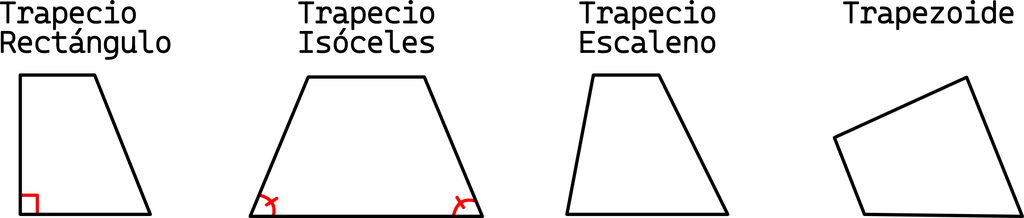

# **Problemas**

## **Problema 1**

Dado los siguientes rectángulos, **sin medir**, comparar en cada caso el área del mismo con el área sombreada.

## **Problema 2**

A partir de un triángulo cualquiera $\triangle ABC$, encontrar un paralelogramo que tenga la misma área que el triángulo.

## **Problema 3**

Comparar las áreas del triángulo con la del paralelogramo ¿Hay algún tipo de relación?

[interactive chart not shown]

# **Applets Problemas**

## **Problema 1**

[interactive chart not shown]

# **Segunda Clase**

## **Resumen**

## **Problema 1**

Dado los siguientes rectángulos, **sin medir**, comparar en cada caso el área del mismo con el área sombreada.

- Trabajo de comparación
- Conjeturas
- Demostración (Postulados elementales y Movimientos en el plano)
- Propiedades
- **Propiedad 1**: La diagonal de un rectángulo lo divide en dos triángulos de áreas iguales.
- **Propiedad 2**: Cuando un triángulo tiene uno de sus lados coincidente con un lado del rectángulo y el vértice restante está contenido en el lado opuesto del rectángulo entonces el área del rectángulo es dos veces el área del triangulo.
- **Propiedad 3**: Si un triángulo y un paralelogramo comparten un lado y el vértice opuesto del triángulo está contenido sobre la recta que contiene al lado opuesto del paralelogramo entonces el área del triángulo es la mitad del área del paralelogramo.
- **Postulado 1**: A toda región poligonal $\mathrm{R}$, le corresponde un **número real positivo único** llamado área, al que designaremos: $\mathrm{A}_R$
- **Postulado 2**: Los triángulos congruentes tienen áreas iguales.
- **Postulado 3**: Si una región $R$ es la unión de dos regiones $R_1$ y $R_2$ entonces: $A_R=A_{R_1}+A_{R_2}$
- **Postulado 4**: El área de una **región rectangular** es el producto de las longitudes de los lados consecutivos. Esto se expresa de la siguiente manera: $A_{rect}=base\cdot altura=b\cdot h$

## **Problema 2**

A partir de un triángulo cualquiera $\triangle ABC$, encontrar un paralelogramo que tenga la misma área que el triángulo.

## **Resoluciones**

### **Resolución del Grupo 1**

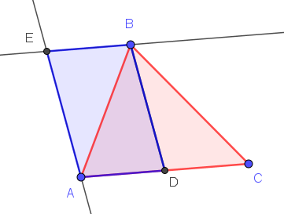

### **Resolución Grupo 2**

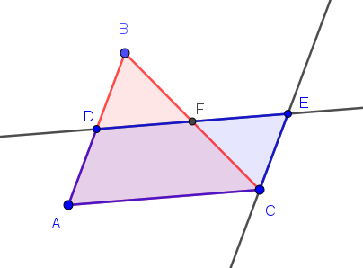

### **Resolución Grupo 3**

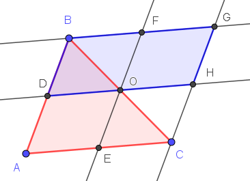

# **Actividades**

## ¿Cómo varía el área de un rectángulo si se duplica la base y no se modifica la altura?

## ¿Y si se triplican ambas?

## **Teorema 1**: El área de un cuadrado es el cuadrado de la longitud de cualquiera de sus lados.

## **Teorema 2**: El área de un triángulo rectángulo es la mitad del producto de las longitudes de los dos catetos.

# **Tarea**

## Dado un rectángulo $\Box ABCD$ cualquiera, encontrar un triángulo cuya **área sea la misma** que la del rectángulo y que **compartan** uno de sus lados.

## Plantear un problema que trabaje el tema **área de polígonos**, donde el camino óptimo para su resolución sea el uso de uno de los postulados.